# Biostat 203B Homework 2

Due Feb 6 @ 11:59PM

Lin-Syuan Yang

```r
knitr::opts_chunk$set(echo = TRUE, cache = TRUE, cache.lazy = FALSE)
library(tidyverse)
library(data.table)
library(lubridate)
```

```r
os <- sessionInfo()$running
if (str_detect(os, "Linux")) {
  mimic_path <- "/mnt/mimiciv/1.0"
} else if (str_detect(os, "macOS")) {
  mimic_path <- "/Users/huazhou/Documents/Box Sync/MIMIC/mimic-iv-1.0"
}
```

In this exercise, we use tidyverse (ggpot2, dplyr, etc) to explore the [MIMIC-IV](https://mimic.mit.edu/docs/iv/) data introduced in [homework 1](https://ucla-biostat-203b.github.io/2022winter/hw/hw1/hw1.html) and to build a cohort of ICU stays.

```r
# tree -s -L 2 /Users/huazhou/Documents/Box\ Sync/MIMIC/mimic-iv-1.0
system(str_c("tree -s -L 2 ", shQuote(mimic_path)), intern = TRUE)
```

```
##  [1] "/mnt/mimiciv/1.0"
##  [2] "├── [       4096]  core"
##  [3] "│   ├── [   17208966]  admissions.csv.gz"
##  [4] "│   ├── [        606]  index.html"
##  [5] "│   ├── [    2955582]  patients.csv.gz"
##  [6] "│   └── [   53014503]  transfers.csv.gz"
##  [7] "├── [       4096]  hosp"
##  [8] "│   ├── [     430049]  d_hcpcs.csv.gz"
##  [9] "│   ├── [   29531152]  diagnoses_icd.csv.gz"
## [10] "│   ├── [     863239]  d_icd_diagnoses.csv.gz"
## [11] "│   ├── [     579998]  d_icd_procedures.csv.gz"
## [12] "│   ├── [      14898]  d_labitems.csv.gz"
## [13] "│   ├── [   11684062]  drgcodes.csv.gz"
## [14] "│   ├── [  515763427]  emar.csv.gz"
## [15] "│   ├── [  476252563]  emar_detail.csv.gz"
```

[output cut: 26 more lines]

## Q1. `read.csv` (base R) vs `read_csv` (tidyverse) vs `fread` (data.table)

There are quite a few utilities in R for reading plain text data files. Let us test the speed of reading a moderate sized compressed csv file, `admissions.csv.gz`, by three programs: `read.csv` in base R, `read_csv` in tidyverse, and `fread` in the popular data.table package.

Which function is fastest? Is there difference in the (default) parsed data types? (Hint: R function `system.time` measures run times.)  
**Answer:**  
From the *elapsed* column we know that `fread` and `read_csv` runs much faster than `read.csv`, and `fread` runs the fastest. Data types differ depending on the function used. `read.csv` gives a `data.frame` class, `read_csv` gives a `tibble` class, and `fread` gives a `data.table` class.

```r
path <- "/mnt/mimiciv/1.0/core/admissions.csv.gz"
system.time(d1 <- read.csv(path))
```

```
##    user  system elapsed
##  45.783   0.249  46.645
```

```r
class(d1)
```

```
## [1] "data.frame"
```

```r
system.time(d2 <- read_csv(path))
```

```
##    user  system elapsed
##   3.495   0.227  16.494
```

```r
class(d2)
```

```
## [1] "spec_tbl_df" "tbl_df"      "tbl"         "data.frame"
```

```r
system.time(d3 <- fread(path))
```

```
##    user  system elapsed
##   1.520   0.134   1.151
```

```r
class(d3)
```

```
## [1] "data.table" "data.frame"
```

For later questions, we stick to the tidyverse.

P.S. Remove unnecessary uasage.

```r
rm(d1, d2, d3)
```

## Q2. ICU stays

`icustays.csv.gz` (https://mimic.mit.edu/docs/iv/modules/icu/icustays/) contains data about Intensive Care Units (ICU) stays. The first 10 lines are

```r
system(
  str_c(
    "zcat < ",
    shQuote(str_c(mimic_path, "/icu/icustays.csv.gz")),
    " | head"
    ),
  intern = TRUE
)
```

```
##  [1] "subject_id,hadm_id,stay_id,first_careunit,last_careunit,intime,outtime,los"
##  [2] "17867402,24528534,31793211,Trauma SICU (TSICU),Trauma SICU (TSICU),2154-03-03 04:11:00,2154-03-04 18:16:56,1.5874537037037035"
##  [3] "14435996,28960964,31983544,Trauma SICU (TSICU),Trauma SICU (TSICU),2150-06-19 17:57:00,2150-06-22 18:33:54,3.025625"
##  [4] "17609946,27385897,33183475,Trauma SICU (TSICU),Trauma SICU (TSICU),2138-02-05 18:54:00,2138-02-15 12:42:05,9.741724537037038"
##  [5] "18966770,23483021,34131444,Trauma SICU (TSICU),Trauma SICU (TSICU),2123-10-25 10:35:00,2123-10-25 18:59:47,0.35054398148148147"
##  [6] "12776735,20817525,34547665,Neuro Stepdown,Neuro Stepdown,2200-07-12 00:33:00,2200-07-13 16:44:40,1.6747685185185184"
##  [7] "10215159,24283593,34569476,Trauma SICU (TSICU),Trauma SICU (TSICU),2124-09-20 15:05:29,2124-09-21 22:06:58,1.2926967592592593"
##  [8] "14489052,26516390,35056286,Trauma SICU (TSICU),Trauma SICU (TSICU),2118-10-26 10:33:56,2118-10-26 20:28:10,0.4126620370370371"
##  [9] "15914763,28906020,36909804,Trauma SICU (TSICU),Trauma SICU (TSICU),2176-12-14 12:00:00,2176-12-17 11:47:01,2.9909837962962964"
## [10] "16256226,20013290,39289362,Neuro Stepdown,Neuro Stepdown,2150-12-20 16:09:08,2150-12-21 14:58:40,0.9510648148148149"
```

1. Import `icustatys.csv.gz` as a tibble `icustays_tble`.  
   **Answer:**

```r
icustays_tble <- read_csv("/mnt/mimiciv/1.0/icu/icustays.csv.gz")
```

2. How many unique `subject_id`? Can a `subject_id` have multiple ICU stays?  
   **Answer:**

```r
unique(icustays_tble$subject_id) %>% length
```

```
## [1] 53150
```

3. For each `subject_id`, let’s only keep the first ICU stay in the tibble `icustays_tble`.  
   **Answer:**

```r
icustays_tble <- icustays_tble %>%
  group_by(subject_id) %>%
  dplyr::arrange(intime, .by_group = TRUE) %>%
  slice_head(n = 1) %>%
  ungroup()
```

## Q3. `admission` data

Information of the patients admitted into hospital is available in `admissions.csv.gz`. See https://mimic.mit.edu/docs/iv/modules/core/admissions/ for details of each field in this file. The first 10 lines are

```r
system(
  str_c(
    "zcat < ",
    shQuote(str_c(mimic_path, "/core/admissions.csv.gz")),
    " | head"
    ),
  intern = TRUE
)
```

```
##  [1] "subject_id,hadm_id,admittime,dischtime,deathtime,admission_type,admission_location,discharge_location,insurance,language,marital_status,ethnicity,edregtime,edouttime,hospital_expire_flag"
##  [2] "14679932,21038362,2139-09-26 14:16:00,2139-09-28 11:30:00,,ELECTIVE,,HOME,Other,ENGLISH,SINGLE,UNKNOWN,,,0"
##  [3] "15585972,24941086,2123-10-07 23:56:00,2123-10-12 11:22:00,,ELECTIVE,,HOME,Other,ENGLISH,,WHITE,,,0"
##  [4] "11989120,21965160,2147-01-14 09:00:00,2147-01-17 14:25:00,,ELECTIVE,,HOME,Other,ENGLISH,,UNKNOWN,,,0"
##  [5] "17817079,24709883,2165-12-27 17:33:00,2165-12-31 21:18:00,,ELECTIVE,,HOME,Other,ENGLISH,,OTHER,,,0"
##  [6] "15078341,23272159,2122-08-28 08:48:00,2122-08-30 12:32:00,,ELECTIVE,,HOME,Other,ENGLISH,,BLACK/AFRICAN AMERICAN,,,0"
##  [7] "19124609,20517215,2169-03-14 12:44:00,2169-03-20 19:15:00,,ELECTIVE,,HOME,Other,ENGLISH,,UNKNOWN,,,0"
##  [8] "17301855,29732723,2140-06-06 14:23:00,2140-06-08 14:25:00,,ELECTIVE,,HOME,Other,ENGLISH,,WHITE,,,0"
##  [9] "17991012,24298836,2181-07-10 20:28:00,2181-07-12 15:49:00,,ELECTIVE,,HOME,Other,ENGLISH,,WHITE,,,0"
## [10] "16865435,23216961,2185-07-19 02:12:00,2185-07-21 11:50:00,,ELECTIVE,,HOME,Other,ENGLISH,,WHITE,,,0"
```

1. Import `admissions.csv.gz` as a tibble `admissions_tble`.  
   **Answer:**

```r
admissions_tble <- read_csv("/mnt/mimiciv/1.0/core/admissions.csv.gz")
```

2. Let’s only keep the admissions that have a match in `icustays_tble` according to `subject_id` and `hadm_id`.  
   **Answer:**

```r
# use `semi_join` to keep rows that matches with icu patients
admissions_tble <- admissions_tble %>%
  semi_join(icustays_tble, by = c("subject_id", "hadm_id"))
```

3. Summarize the following variables by graphics.  
   **Answer:**
- admission year

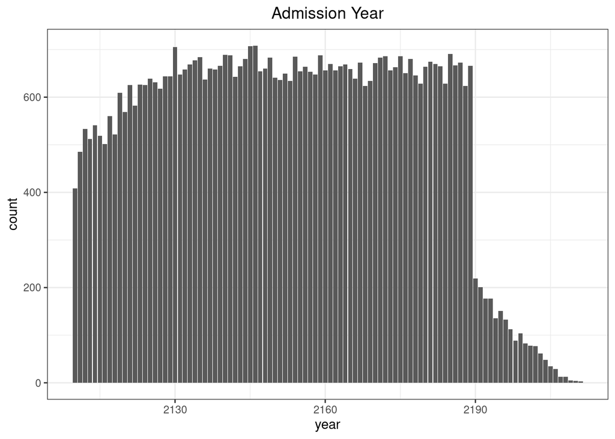

```r
admissions_tble %>%
  mutate(year = year(admittime)) %>%
  ggplot(aes(x = year)) +
  geom_bar() +
  theme_bw() +
  ggtitle("Admission Year") +
  theme(plot.title = element_text(hjust = 0.5))
```

- admission month

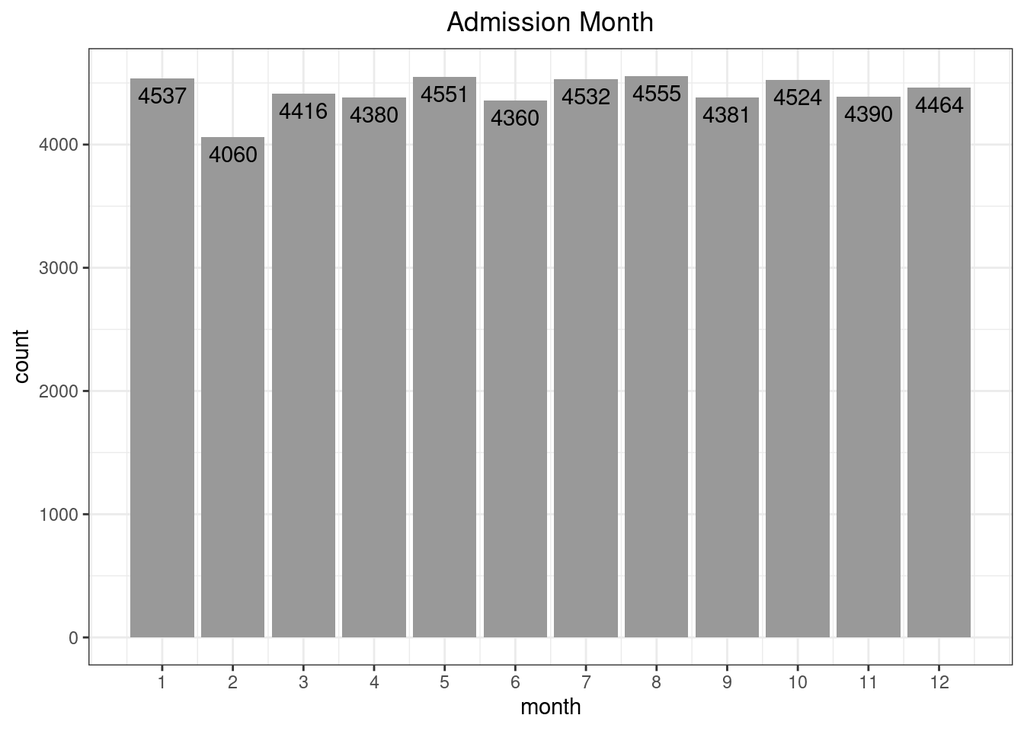

```r
admissions_tble %>%
  mutate(month = month(admittime)) %>%
  ggplot(aes(x = month)) +
  geom_bar(fill = "grey60") +
  geom_text(stat = "count", aes(label = ..count..), vjust = 1.5) +
  scale_x_continuous(breaks = seq(1, 12, 1)) +
  theme_bw() +
  ggtitle("Admission Month") +
  theme(plot.title = element_text(hjust = 0.5))
```

- admission month day

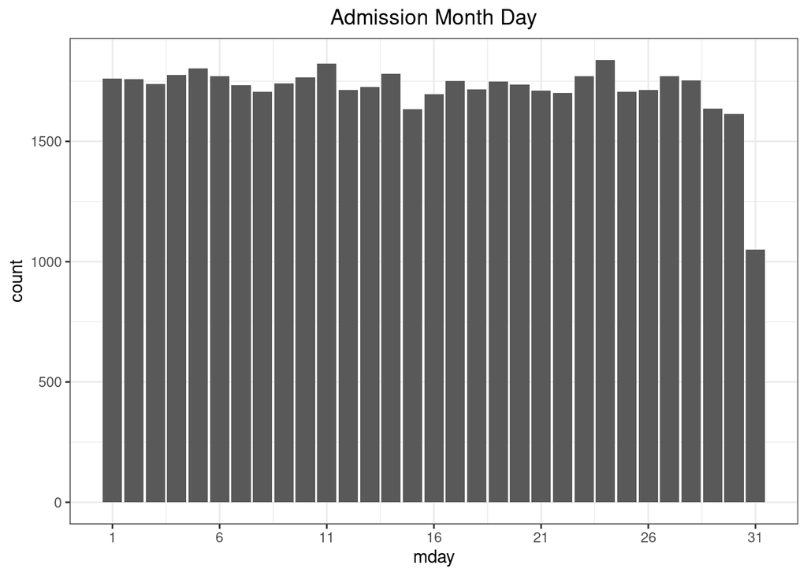

```r
admissions_tble %>%
  mutate(mday = mday(admittime)) %>%
  ggplot(aes(x = mday)) +
  geom_bar() +
  scale_x_continuous(breaks = seq(1, 31, 5)) +
  theme_bw() +
  ggtitle("Admission Month Day") +
  theme(plot.title = element_text(hjust = 0.5))
```

- admission hour (anything unusual?) The hour starts from `0` to `23`.

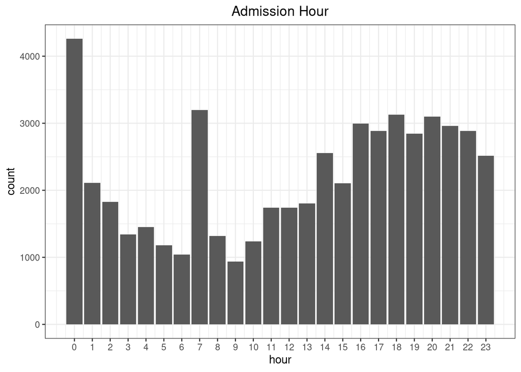

```r
admissions_tble %>%
  mutate(hour = hour(admittime)) %>%
  ggplot(aes(x = hour)) +
  geom_bar() +
  scale_x_continuous(breaks = seq(0, 23, 1)) +
  theme_bw() +
  ggtitle("Admission Hour") +
  theme(plot.title = element_text(hjust = 0.5))
```

- admission week day

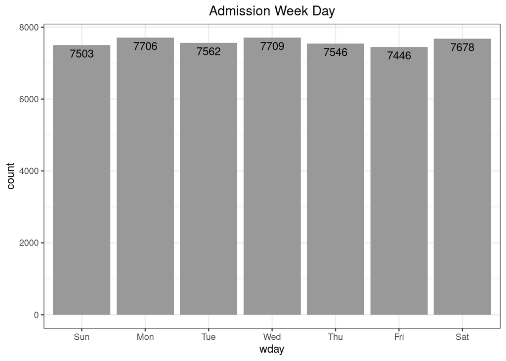

```r
admissions_tble %>%
  mutate(wday = wday(admittime, label = TRUE)) %>%
  ggplot(aes(x = wday)) +
  geom_bar(fill = "grey60") +
  geom_text(stat = "count", aes(label = ..count..), vjust = 1.5) +
  theme_bw() +
  ggtitle("Admission Week Day") +
  theme(plot.title = element_text(hjust = 0.5))
```

## Q4. `patients` data

Patient information is available in `patients.csv.gz`. See https://mimic.mit.edu/docs/iv/modules/core/patients/ for details of each field in this file. The first 10 lines are

```r
system(
  str_c(
    "zcat < ",
    shQuote(str_c(mimic_path, "/core/patients.csv.gz")),
    " | head"
    ),
  intern = TRUE
)
```

```
##  [1] "subject_id,gender,anchor_age,anchor_year,anchor_year_group,dod"
##  [2] "10000048,F,23,2126,2008 - 2010,"
##  [3] "10002723,F,0,2128,2017 - 2019,"
##  [4] "10003939,M,0,2184,2008 - 2010,"
##  [5] "10004222,M,0,2161,2014 - 2016,"
##  [6] "10005325,F,0,2154,2011 - 2013,"
##  [7] "10007338,F,0,2153,2017 - 2019,"
##  [8] "10008101,M,0,2142,2008 - 2010,"
##  [9] "10009872,F,0,2168,2014 - 2016,"
## [10] "10011333,F,0,2132,2014 - 2016,"
```

1. Import `patients.csv.gz` (https://mimic.mit.edu/docs/iv/modules/core/patients/) as a tibble `patients_tble` and only keep the patients who have a match in `icustays_tble` (according to `subject_id`).  
   **Answer:**

```r
patients_tble <- read_csv("/mnt/mimiciv/1.0/core/patients.csv.gz") %>%
  semi_join(icustays_tble, by = "subject_id")
```

```r
patients_tble %>%
  group_by(gender) %>%
  dplyr::summarise(
    count = dplyr::n(),
    min_age = min(anchor_age),
    mean_age = mean(anchor_age),
    median_age = median(anchor_age),
    max_age = max(anchor_age)
  )
```

```
## # A tibble: 2 × 6
##   gender count min_age mean_age median_age max_age
##   <chr>  <int>   <dbl>    <dbl>      <dbl>   <dbl>
## 1 F      23353      18     64.8         67      91
## 2 M      29797      18     62.5         64      91
```

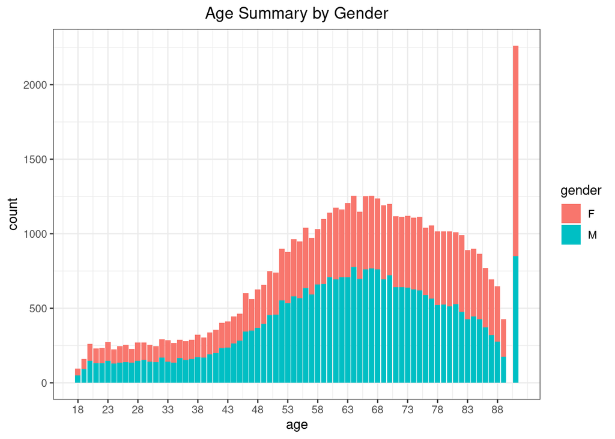

```r
patients_tble %>%
  ggplot(aes(x = anchor_age, fill = gender)) +
  geom_bar() +
  scale_x_continuous(breaks = seq(18, 92, 5)) +
  theme_bw() +
  labs(title = "Age Summary by Gender", x = "age") +
  theme(plot.title = element_text(hjust = 0.5))
```

## Q5. Lab results

`labevents.csv.gz` (https://mimic.mit.edu/docs/iv/modules/hosp/labevents/) contains all laboratory measurements for patients. The first 10 lines are

```r
system(
  str_c(
    "zcat < ",
    shQuote(str_c(mimic_path, "/hosp/labevents.csv.gz")),
    " | head"
    ),
  intern = TRUE
)
```

```
##  [1] "labevent_id,subject_id,hadm_id,specimen_id,itemid,charttime,storetime,value,valuenum,valueuom,ref_range_lower,ref_range_upper,flag,priority,comments"
##  [2] "670,10000048,,6448755,51484,2126-11-22 19:20:00,2126-11-22 20:07:00,150,150,mg/dL,,,,STAT,"
##  [3] "673,10000048,,6448755,51491,2126-11-22 19:20:00,2126-11-22 20:07:00,6.5,6.5,units,5,8,,STAT,"
##  [4] "675,10000048,,6448755,51498,2126-11-22 19:20:00,2126-11-22 20:07:00,1.029,1.029, ,1.001,1.035,,STAT,"
##  [5] "683,10000048,,82729055,50861,2126-11-22 20:45:00,2126-11-23 00:55:00,39,39,IU/L,0,40,,STAT,"
##  [6] "684,10000048,,82729055,50862,2126-11-22 20:45:00,2126-11-23 00:55:00,4.7,4.7,g/dL,3.4,4.8,,STAT,"
##  [7] "685,10000048,,82729055,50863,2126-11-22 20:45:00,2126-11-23 00:55:00,45,45,IU/L,39,117,,STAT,"
##  [8] "686,10000048,,82729055,50868,2126-11-22 20:45:00,2126-11-22 21:32:00,13,13,mEq/L,8,20,,STAT,"
##  [9] "687,10000048,,82729055,50878,2126-11-22 20:45:00,2126-11-23 00:55:00,28,28,IU/L,0,40,,STAT,"
## [10] "688,10000048,,82729055,50882,2126-11-22 20:45:00,2126-11-22 21:32:00,26,26,mEq/L,22,32,,STAT,"
```

`d_labitems.csv.gz` is the dictionary of lab measurements.

```r
system(
  str_c(
    "zcat < ",
    shQuote(str_c(mimic_path, "/hosp/d_labitems.csv.gz")),
    " | head"
    ),
  intern = TRUE
)
```

```
##  [1] "itemid,label,fluid,category,loinc_code"
##  [2] "51905, ,Other Body Fluid,Chemistry,"
##  [3] "51532,11-Deoxycorticosterone,Blood,Chemistry,"
##  [4] "51957,17-Hydroxycorticosteroids,Urine,Chemistry,"
##  [5] "51958,\"17-Ketosteroids, Urine\",Urine,Chemistry,"
##  [6] "52068,24 Hr,Blood,Hematology,"
##  [7] "51066,24 hr Calcium,Urine,Chemistry,"
##  [8] "51067,24 hr Creatinine,Urine,Chemistry,"
##  [9] "51068,24 hr Protein,Urine,Chemistry,"
## [10] "50853,25-OH Vitamin D,Blood,Chemistry,"
```

1. Find how many rows are in `labevents.csv.gz`.  
   **Answer:**

```bash
wc -l /mnt/mimiciv/1.0/hosp/labevents_filtered_itemid.csv.gz
```

```
## 553001 /mnt/mimiciv/1.0/hosp/labevents_filtered_itemid.csv.gz
```

2. We are interested in the lab measurements of creatinine (50912), potassium (50971), sodium (50983), chloride (50902), bicarbonate (50882), hematocrit (51221), white blood cell count (51301), glucose (50931), magnesium (50960), and calcium (50893). Retrieve a subset of `labevents.csv.gz` only containing these items for the patients in `icustays_tble` as a tibble `labevents_tble`.

   Hint: `labevents.csv.gz` is a data file too big to be read in by the `read_csv` function in its default setting. Utilize the `col_select` and `lazy` options in the `read_csv` function to reduce the memory burden.
3. Further restrict `labevents_tble` to the first lab measurement during the ICU stay.  
   **Answer:**

```r
labevents_tble <-
  read_csv("/mnt/mimiciv/1.0/hosp/labevents_filtered_itemid.csv.gz",
           col_select = c("subject_id", "charttime", "itemid", "valuenum"),
           lazy = TRUE) %>%
  semi_join(icustays_tble, by = "subject_id")

# restrict to the first lab measurement during the ICU stay
labevents_tble <- labevents_tble %>%
  # pull in intime
  left_join(select(icustays_tble, subject_id, intime), key = "subject_id") %>%
  # make sure measurement time not prior to first icu stay
  filter(charttime >= intime) %>%
  # keep first lab measurement after intime
  group_by(subject_id, itemid) %>%
  dplyr::arrange(charttime, .by_group = TRUE) %>%
  slice_head(n = 1) %>%
  ungroup()

# Rename the itemid
labevents_tble$itemid <- recode_factor(labevents_tble$itemid,
                                       `50912` = "creatinine",
                                       `50971` = "potassium",
                                       `50983` = "sodium",
                                       `50902` = "chloride",
                                       `50882` = "bicarbonate",
                                       `51221` = "hematocrit",
                                       `51301` = "wbcc",
                                       `50931` = "glucose",
                                       `50960` = "magnesium",
                                       `50893` = "calcium")
```

4. Summarize the lab measurements by appropriate numerics and graphics.  
   **Answer:**  
   This summary table includes the minimum, 25th percentile, mean, median, 75th percentile, maximum values, as well as NA and total counts.

```r
# summary table
labevents_tble %>%
  group_by(itemid) %>%
  dplyr::summarise(min = min(valuenum, na.rm = T),
                   Q1 = quantile(valuenum, .25, na.rm = T),
                   mean = mean(valuenum, na.rm = T),
                   median = median(valuenum, na.rm = T),
                   Q3 = quantile(valuenum, .75, na.rm = T),
                   max = max(valuenum, na.rm = T),
                   # count of NAs
                   na = sum(is.na(valuenum)),
                   N = n())
```

```
## # A tibble: 10 × 9
##    itemid        min    Q1   mean median    Q3    max    na     N
##    <fct>       <dbl> <dbl>  <dbl>  <dbl> <dbl>  <dbl> <int> <int>
##  1 creatinine    0     0.7   1.31    0.9   1.3   36.9    13 52470
##  2 potassium     0.8   3.7   4.18    4.1   4.5   13      39 52468
##  3 sodium       92   136   139.    139   141    180       7 52467
##  4 chloride     58   101   104.    105   108    153      13 52461
##  5 bicarbonate   2    21    23.0    23    25     49      26 52451
##  6 hematocrit    4.3  28.1  32.8    32.7  37.3   68.6   204 52456
##  7 wbcc          0     7.6  12.0    10.5  14.4  572.    183 52435
##  8 glucose       7   103   141.    124   156   2440       6 52443
##  9 magnesium     0     1.7   2.00    2     2.2   47       7 52293
## 10 calcium       0     7.9   8.37    8.4   8.9   43       5 51308
```

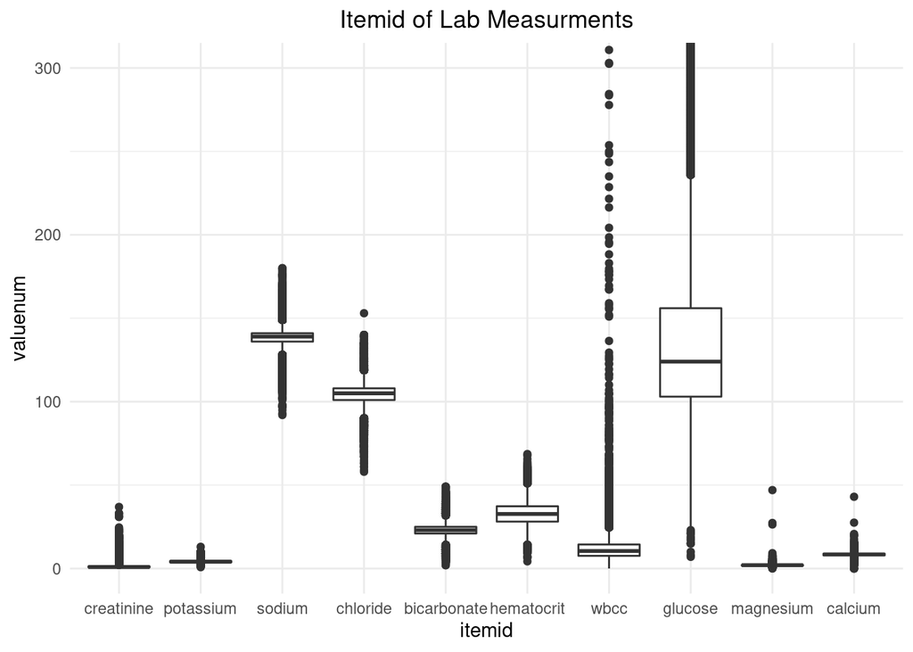

```r
# boxplot
labevents_tble %>%
  mutate(itemid = factor(itemid)) %>%
  ggplot(aes(x = itemid, y = valuenum)) +
  geom_boxplot() +
  coord_cartesian(ylim = c(0, 300)) +
  # scale_fill_brewer(palette = "RdBu") +
  theme_minimal() +
  labs(title = "Itemid of Lab Measurments") +
  theme(plot.title = element_text(hjust = 0.5))
```

## Q6. Vitals from charted events

`chartevents.csv.gz` (https://mimic.mit.edu/docs/iv/modules/icu/chartevents/) contains all the charted data available for a patient. During their ICU stay, the primary repository of a patient’s information is their electronic chart. The `itemid` variable indicates a single measurement type in the database. The `value` variable is the value measured for `itemid`. The first 10 lines of `chartevents.csv.gz` are

```r
system(
  str_c(
    "zcat < ",
    shQuote(str_c(mimic_path, "/icu/chartevents.csv.gz")),
    " | head"),
  intern = TRUE
)
```

```
##  [1] "subject_id,hadm_id,stay_id,charttime,storetime,itemid,value,valuenum,valueuom,warning"
##  [2] "10003700,28623837,30600691,2165-04-24 05:10:00,2165-04-24 05:11:00,228236,0,0,,0"
##  [3] "10003700,28623837,30600691,2165-04-24 05:12:00,2165-04-24 05:14:00,225067,0,0,,0"
##  [4] "10003700,28623837,30600691,2165-04-24 05:12:00,2165-04-24 05:14:00,225070,1,1,,0"
##  [5] "10003700,28623837,30600691,2165-04-24 05:12:00,2165-04-24 05:14:00,225076,1,1,,0"
##  [6] "10003700,28623837,30600691,2165-04-24 05:12:00,2165-04-24 05:14:00,225078,1,1,,0"
##  [7] "10003700,28623837,30600691,2165-04-24 05:12:00,2165-04-24 05:14:00,225086,1,1,,0"
##  [8] "10003700,28623837,30600691,2165-04-24 05:12:00,2165-04-24 05:14:00,225091,1,1,,0"
##  [9] "10003700,28623837,30600691,2165-04-24 05:12:00,2165-04-24 05:14:00,225103,1,1,,0"
## [10] "10003700,28623837,30600691,2165-04-24 05:12:00,2165-04-24 05:14:00,225106,1,1,,0"
```

`d_items.csv.gz` (https://mimic.mit.edu/docs/iv/modules/icu/d_items/) is the dictionary for the `itemid` in `chartevents.csv.gz`.

```r
system(
  str_c(
    "zcat < ",
    shQuote(str_c(mimic_path, "/icu/d_items.csv.gz")),
    " | head"),
  intern = TRUE
)
```

```
##  [1] "itemid,label,abbreviation,linksto,category,unitname,param_type,lownormalvalue,highnormalvalue"
##  [2] "220003,ICU Admission date,ICU Admission date,datetimeevents,ADT,,Date and time,,"
##  [3] "220045,Heart Rate,HR,chartevents,Routine Vital Signs,bpm,Numeric,,"
##  [4] "220046,Heart rate Alarm - High,HR Alarm - High,chartevents,Alarms,bpm,Numeric,,"
##  [5] "220047,Heart Rate Alarm - Low,HR Alarm - Low,chartevents,Alarms,bpm,Numeric,,"
##  [6] "220048,Heart Rhythm,Heart Rhythm,chartevents,Routine Vital Signs,,Text,,"
##  [7] "220050,Arterial Blood Pressure systolic,ABPs,chartevents,Routine Vital Signs,mmHg,Numeric,90,140"
##  [8] "220051,Arterial Blood Pressure diastolic,ABPd,chartevents,Routine Vital Signs,mmHg,Numeric,60,90"
##  [9] "220052,Arterial Blood Pressure mean,ABPm,chartevents,Routine Vital Signs,mmHg,Numeric,,"
## [10] "220056,Arterial Blood Pressure Alarm - Low,ABP Alarm - Low,chartevents,Alarms,mmHg,Numeric,,"
```

1. We are interested in the vitals for ICU patients: heart rate (220045), mean non-invasive blood pressure (220181), systolic non-invasive blood pressure (220179), body temperature in Fahrenheit (223761), and respiratory rate (220210). Retrieve a subset of `chartevents.csv.gz` only containing these items for the patients in `icustays_tble` as a tibble `chartevents_tble`.
2. Further restrict `chartevents_tble` to the first vital measurement during the ICU stay.  
   **Answer:**

```r
chartevents_tble <-
  read_csv("/mnt/mimiciv/1.0/icu/chartevents_filtered_itemid.csv.gz",
           col_select = c("subject_id", "charttime", "itemid", "valuenum"),
           lazy = TRUE) %>%
  left_join(select(icustays_tble, subject_id, intime), key = "subject_id") %>%
  filter(charttime >= intime) %>%
  group_by(subject_id, itemid) %>%
  dplyr::arrange(charttime, .by_group = TRUE) %>%
  slice_head(n = 1) %>%
  ungroup()

# Rename the itemid
chartevents_tble$itemid <- recode_factor(chartevents_tble$itemid,
                                         `220045` = "heart_rate",
                                         `220181` = "mnibp",
                                         `220179` = "snibp",
                                         `223761` = "body_temp",
                                         `220210` = "resp")
```

3. Summarize these vital measurements by appropriate numerics and graphics.  
   **Answer:**  
   This summary table includes the minimum, 25th percentile, mean, median, 75th percentile, maximum values, as well as NA and total counts.

```r
chartevents_tble %>%
  group_by(itemid) %>%
  dplyr::summarise(min = min(valuenum, na.rm = T),
                   Q1 = quantile(valuenum, .25, na.rm = T),
                   mean = mean(valuenum, na.rm = T),
                   median = median(valuenum, na.rm = T),
                   Q3 = quantile(valuenum, .75, na.rm = T),
                   max = max(valuenum, na.rm = T),
                   # count of NAs
                   na = sum(is.na(valuenum)),
                   N = n())
```

```
## # A tibble: 5 × 9
##   itemid       min    Q1  mean median    Q3    max    na     N
##   <fct>      <dbl> <dbl> <dbl>  <dbl> <dbl>  <dbl> <int> <int>
## 1 heart_rate     0  74    87.5   85    99      941     0 53149
## 2 mnibp          0  70    87.4   81    93   140119     0 52617
## 3 snibp          0 106   124.   122   139    12262     0 52638
## 4 body_temp      0  97.6  98.0   98.1  98.7    106     0 52330
## 5 resp           0  15    18.7   18    22      180     0 53113
```

Given the extreme outliers in `itemid` systolic non-invasive blood pressure (220179) and mean non-invasive blood pressure(220181), the y axis limit of boxplot below is set to 250 for better visualization.

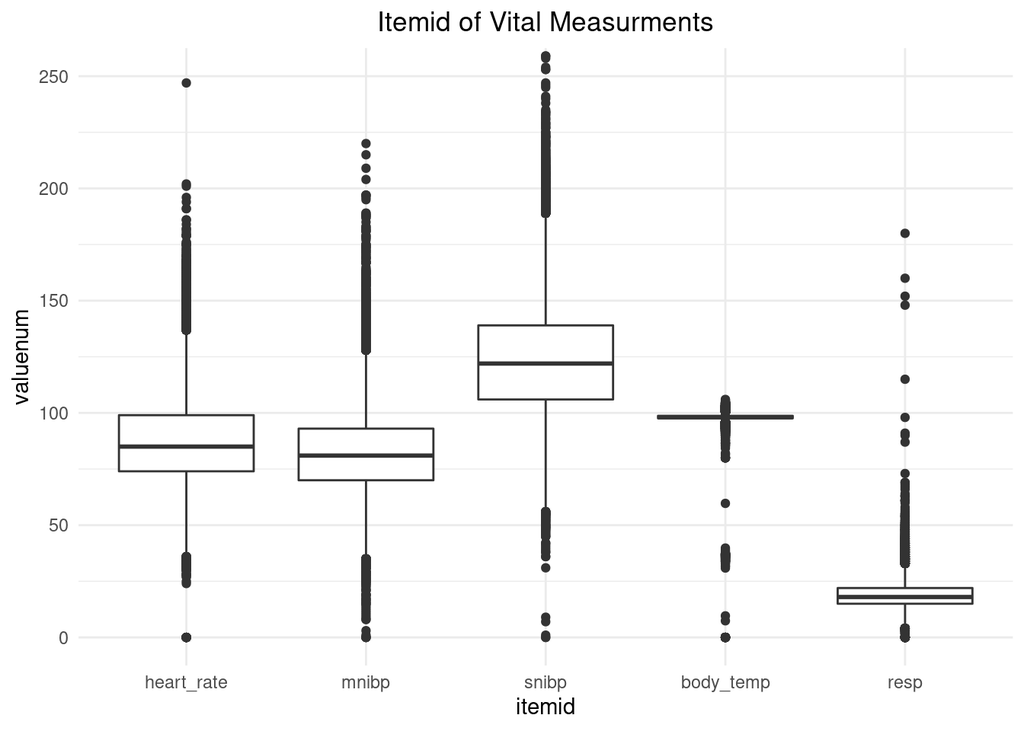

```r
# boxplot
chartevents_tble %>%
  mutate(itemid = factor(itemid)) %>%
  ggplot(aes(x = itemid, y = valuenum)) +
  geom_boxplot() +
  coord_cartesian(ylim = c(0, 250)) +
  theme_minimal() +
  labs(title = "Itemid of Vital Measurments") +
  theme(plot.title = element_text(hjust = 0.5))
```

## Q7. Putting things together

Let us create a tibble `mimic_icu_cohort` for all ICU stays, where rows are

- first ICU stay of each unique adult (age at admission > 18)

and columns contain at least following variables  
- all variables in `icustays.csv.gz`  
- all variables in `admission.csv.gz`  
- all variables in `patients.csv.gz`  
- first lab measurements during ICU stay  
- first vital measurements during ICU stay  
- an indicator variable `thirty_day_mort` whether the patient died within 30 days of hospital admission (30 day mortality)

**Answer:**  
1. Merge all datasets based on `subject_id` in `icustays_tble`.  
2. Create a variable for age at admission: age_hadm = anchor_age + year(admittime) - anchor_year. Then filter the age.  
3. Spread the dataframe by `itemid`. Ignore `charttime` because it could be different across `labevents_tble` and `chartevents_tble`.  
4. Define `thirty_day_mort`: `thirty_day_mort` = 0 if the patient didn’t die or did die after 30 days upon admission.

```r
measurements <- rbind(
  chartevents_tble %>% select(subject_id, itemid, valuenum),
  labevents_tble %>% select(subject_id, itemid, valuenum)
)
rm(labevents_tble, chartevents_tble)

mimic_icu_cohort <- icustays_tble %>%
  # merge all dataset by `subject_id`
  left_join(patients_tble, key = "subject_id") %>%
  left_join(., admissions_tble, key = "subject_id") %>%
  left_join(., measurements, key = "subject_id") %>%
  mutate(
    # deathtime - admittime: time difference in mins
    diff = deathtime - admittime,
    # thirty_day_mort = 0 if diff > 30 days | is.na(diff)
    thirty_day_mort = ifelse(is.na(diff), 0, ifelse(diff < 30*24*60, 1, 0))
    ) %>%
  # filter the age at admission
  mutate(age_hadm = anchor_age + year(admittime) - anchor_year) %>%
  filter(age_hadm > 18) %>%
  # create unique identifier rows
  group_by(subject_id, itemid) %>%
  dplyr::mutate(row = row_number()) %>%
  pivot_wider(names_from = itemid,
              values_from = valuenum) %>%
  select(-c(row, diff))
```

```r
rm(measurements, icustays_tble, patients_tble, admissions_tble)
```

## Q8. Exploratory data analysis (EDA)

Summarize following information using appropriate numerics or graphs.

- `thirty_day_mort` vs demographic variables (ethnicity, language, insurance, marital_status, gender, age at hospital admission).  
  **Answer:**
1. Categorical variables: ethnicity, language, insurance, marital_status, and gender

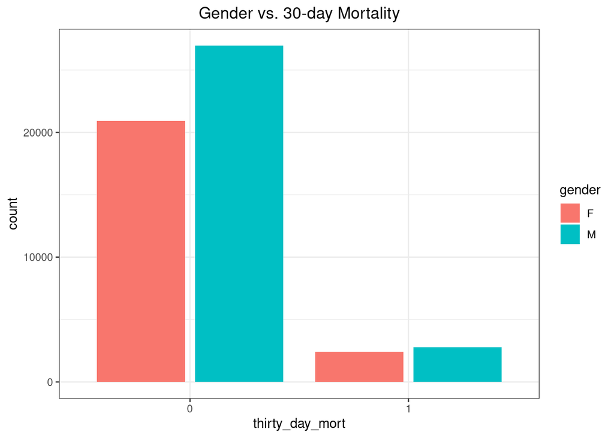

```r
# gender
mimic_icu_cohort %>%
  ggplot(aes(x = factor(as.character(thirty_day_mort)), fill = gender)) +
  geom_bar(position = "dodge2") +
  labs(title = "Gender vs. 30-day Mortality", x = "thirty_day_mort",
       y = "count") +
  theme_bw() +
  theme(plot.title = element_text(hjust = 0.5))
```

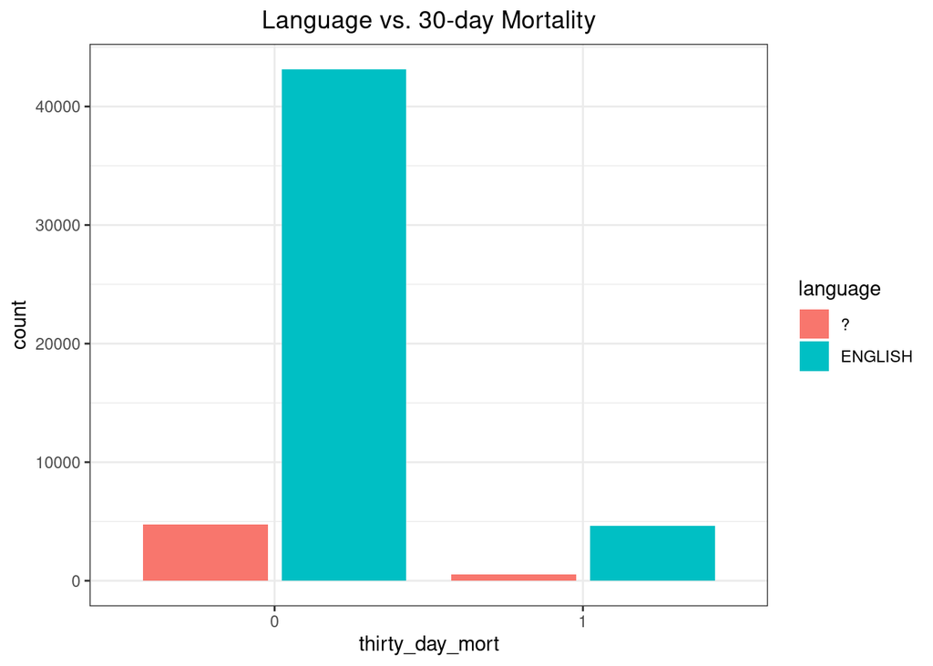

```r
# language
mimic_icu_cohort %>%
  ggplot(aes(x = factor(as.character(thirty_day_mort)), fill = language)) +
  geom_bar(position = "dodge2") +
  labs(title = "Language vs. 30-day Mortality", x = "thirty_day_mort",
       y = "count") +
  theme_bw() +
  theme(plot.title = element_text(hjust = 0.5))
```

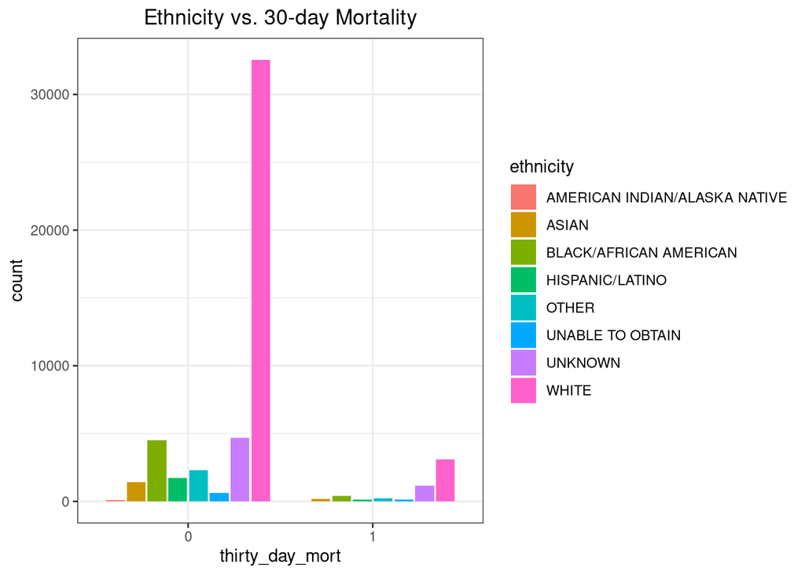

```r
# ethnicity
mimic_icu_cohort %>%
  ggplot(aes(x = factor(as.character(thirty_day_mort)), fill = ethnicity)) +
  geom_bar(position = "dodge2") +
  labs(title = "Ethnicity vs. 30-day Mortality", x = "thirty_day_mort",
       y = "count") +
  theme_bw() +
  theme(plot.title = element_text(hjust = 0.5))
```

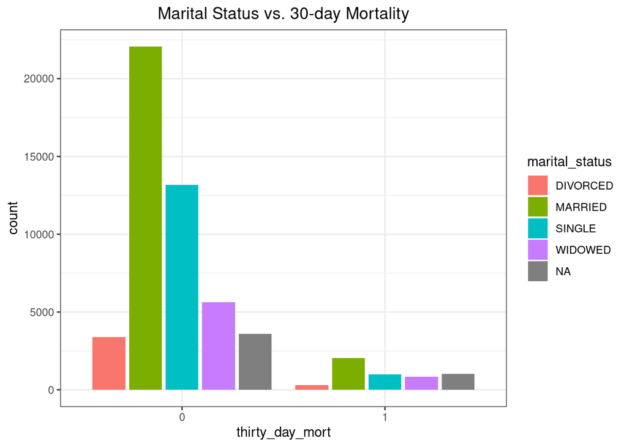

```r
# marital_status
mimic_icu_cohort %>%
  ggplot(aes(x = factor(as.character(thirty_day_mort)), fill = marital_status)) +
  geom_bar(position = "dodge2") +
  labs(title = "Marital Status vs. 30-day Mortality", x = "thirty_day_mort",
       y = "count") +
  theme_bw() +
  theme(plot.title = element_text(hjust = 0.5))
```

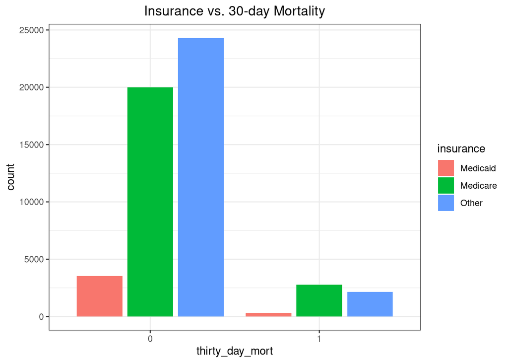

```r
# insurance
mimic_icu_cohort %>%
  ggplot(aes(x = factor(as.character(thirty_day_mort)), fill = insurance)) +
  geom_bar(position = "dodge2") +
  labs(title = "Insurance vs. 30-day Mortality", x = "thirty_day_mort",
       y = "count") +
  theme_bw() +
  theme(plot.title = element_text(hjust = 0.5))
```

2. Continuous variable: age at hospital admission

```r
mimic_icu_cohort %>%
  group_by(thirty_day_mort) %>%
  dplyr::summarise(min = min(age_hadm, na.rm = T),
                   Q1 = quantile(age_hadm, .25, na.rm = T),
                   mean = mean(age_hadm, na.rm = T),
                   median = median(age_hadm, na.rm = T),
                   Q3 = quantile(age_hadm, .75, na.rm = T),
                   max = max(age_hadm, na.rm = T),
                   # count of NAs
                   na = sum(is.na(age_hadm)),
                   N = n())
```

```
## # A tibble: 2 × 9
##   thirty_day_mort   min    Q1  mean median    Q3   max    na     N
##             <dbl> <dbl> <dbl> <dbl>  <dbl> <dbl> <dbl> <int> <int>
## 1               0    19    53  63.8     66    77   102     0 47855
## 2               1    19    61  71.3     74    84   100     0  5210
```

- `thirty_day_mort` vs first lab measurements  
  **Answer:**  
  Overall boxplot

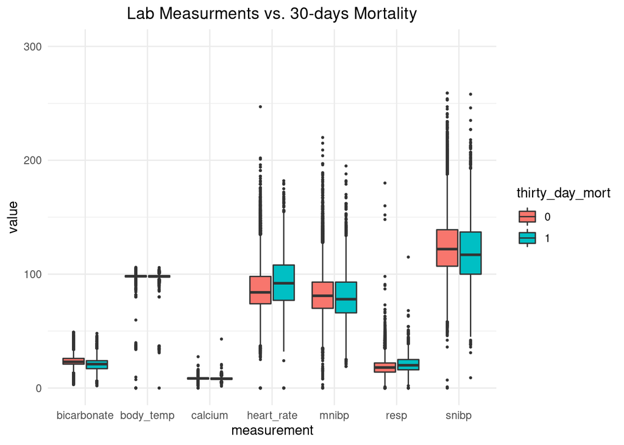

```r
# lengthen the data for measurements
df <- mimic_icu_cohort %>%
  pivot_longer(cols = heart_rate:calcium,
               names_to = "measurement", values_to = "value") %>%
  mutate(measurement = factor(measurement),
         # convert thirty_day_mort to a factor for plotting
         thirty_day_mort = factor(as.character(thirty_day_mort)))

# Overview of all first lab measurements
df %>%
  ggplot(aes(x = factor(measurement), y = value, fill = thirty_day_mort)) +
  geom_boxplot(outlier.size = 0.5) +
  coord_cartesian(ylim = c(0, 300)) +
  theme_minimal() +
  labs(title = "Lab Measurments vs. 30-days Mortality",
       x = "measurement") +
  theme(plot.title = element_text(hjust = 0.5))
```

1. creatinine

```r
# summary
mimic_icu_cohort %>%
  group_by(thirty_day_mort) %>%
  dplyr::summarise(min = min(creatinine, na.rm = T),
                   Q1 = quantile(creatinine, .25, na.rm = T),
                   mean = mean(creatinine, na.rm = T),
                   median = median(creatinine, na.rm = T),
                   Q3 = quantile(creatinine, .75, na.rm = T),
                   max = max(creatinine, na.rm = T),
                   # count of NAs
                   na = sum(is.na(creatinine)),
                   N = n())
```

```
## # A tibble: 2 × 9
##   thirty_day_mort   min    Q1  mean median    Q3   max    na     N
##             <dbl> <dbl> <dbl> <dbl>  <dbl> <dbl> <dbl> <int> <int>
## 1               0   0     0.7  1.26    0.9   1.2  36.9   279 47855
## 2               1   0.1   0.8  1.78    1.3   2.1  23.1   410  5210
```

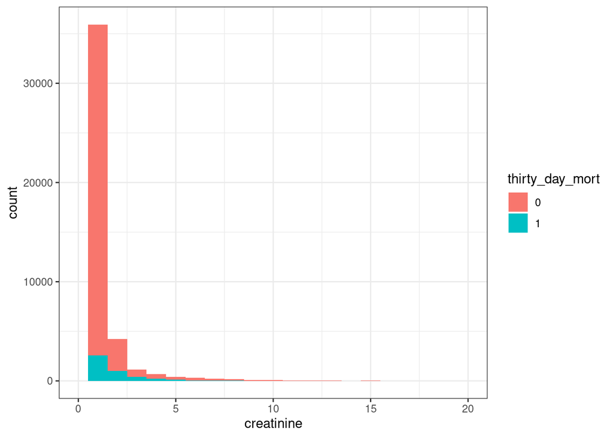

```r
# histogram
mimic_icu_cohort %>%
  mutate(thirty_day_mort = factor(as.character(thirty_day_mort))) %>%
  ggplot(aes(x = creatinine, fill = thirty_day_mort)) +
  geom_histogram(position = "identity", binwidth = 1) +
  xlim(0, 20) +
  theme_bw()
```

2. potassium

```r
# summary
mimic_icu_cohort %>%
  group_by(thirty_day_mort) %>%
  dplyr::summarise(min = min(potassium, na.rm = T),
                   Q1 = quantile(potassium, .25, na.rm = T),
                   mean = mean(potassium, na.rm = T),
                   median = median(potassium, na.rm = T),
                   Q3 = quantile(potassium, .75, na.rm = T),
                   max = max(potassium, na.rm = T),
                   # count of NAs
                   na = sum(is.na(potassium)),
                   N = n())
```

```
## # A tibble: 2 × 9
##   thirty_day_mort   min    Q1  mean median    Q3   max    na     N
##             <dbl> <dbl> <dbl> <dbl>  <dbl> <dbl> <dbl> <int> <int>
## 1               0   0.8   3.7  4.16    4.1   4.5  13     313 47855
## 2               1   1.4   3.7  4.33    4.2   4.8   9.6   404  5210
```

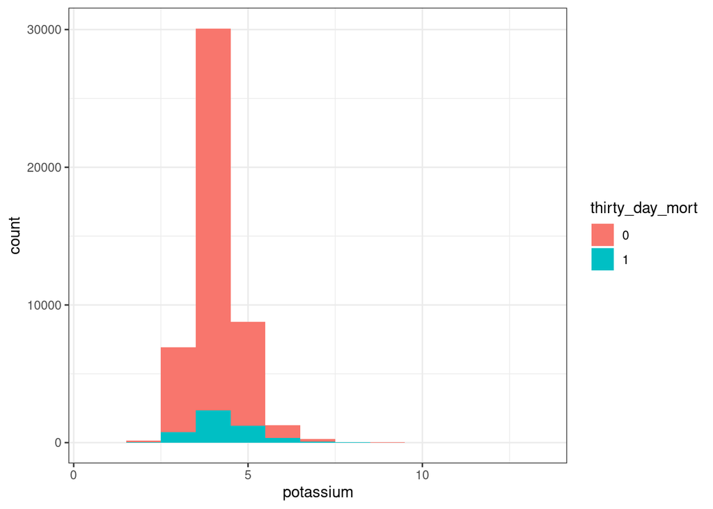

```r
# histogram
mimic_icu_cohort %>%
  mutate(thirty_day_mort = factor(as.character(thirty_day_mort))) %>%
  ggplot(aes(x = potassium, fill = thirty_day_mort)) +
  geom_histogram(position = "identity", binwidth = 1) +
  theme_bw()
```

3. sodium

```r
# summary
mimic_icu_cohort %>%
  group_by(thirty_day_mort) %>%
  dplyr::summarise(min = min(sodium, na.rm = T),
                   Q1 = quantile(sodium, .25, na.rm = T),
                   mean = mean(sodium, na.rm = T),
                   median = median(sodium, na.rm = T),
                   Q3 = quantile(sodium, .75, na.rm = T),
                   max = max(sodium, na.rm = T),
                   # count of NAs
                   na = sum(is.na(sodium)),
                   N = n())
```

```
## # A tibble: 2 × 9
##   thirty_day_mort   min    Q1  mean median    Q3   max    na     N
##             <dbl> <dbl> <dbl> <dbl>  <dbl> <dbl> <dbl> <int> <int>
## 1               0    92   136  139.    139   141   180   285 47855
## 2               1    97   135  138.    139   142   176   400  5210
```

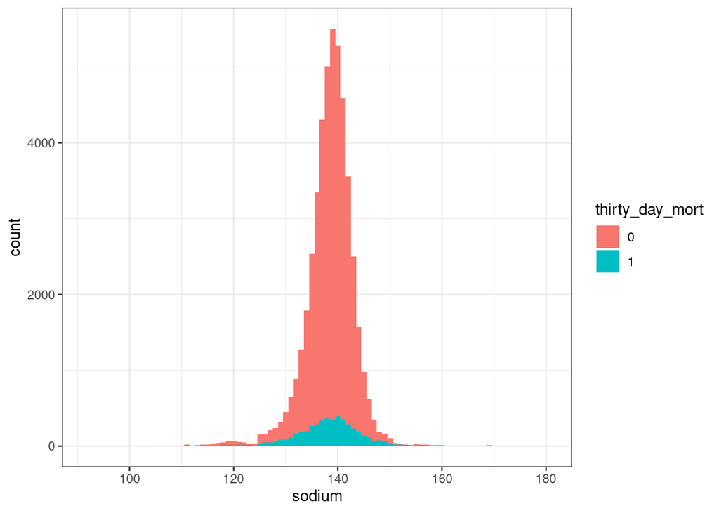

```r
# histogram
mimic_icu_cohort %>%
  mutate(thirty_day_mort = factor(as.character(thirty_day_mort))) %>%
  ggplot(aes(x = sodium, fill = thirty_day_mort)) +
  geom_histogram(position = "identity", binwidth = 1) +
  theme_bw()
```

4. hematocrit

```r
# summary
mimic_icu_cohort %>%
  group_by(thirty_day_mort) %>%
  dplyr::summarise(min = min(hematocrit, na.rm = T),
                   Q1 = quantile(hematocrit, .25, na.rm = T),
                   mean = mean(hematocrit, na.rm = T),
                   median = median(hematocrit, na.rm = T),
                   Q3 = quantile(hematocrit, .75, na.rm = T),
                   max = max(hematocrit, na.rm = T),
                   # count of NAs
                   na = sum(is.na(hematocrit)),
                   N = n())
```

```
## # A tibble: 2 × 9
##   thirty_day_mort   min    Q1  mean median    Q3   max    na     N
##             <dbl> <dbl> <dbl> <dbl>  <dbl> <dbl> <dbl> <int> <int>
## 1               0   6.4  28.2  32.8   32.7  37.3  68.6   457 47855
## 2               1   4.3  27.4  32.5   32.1  37.2  62.1   433  5210
```

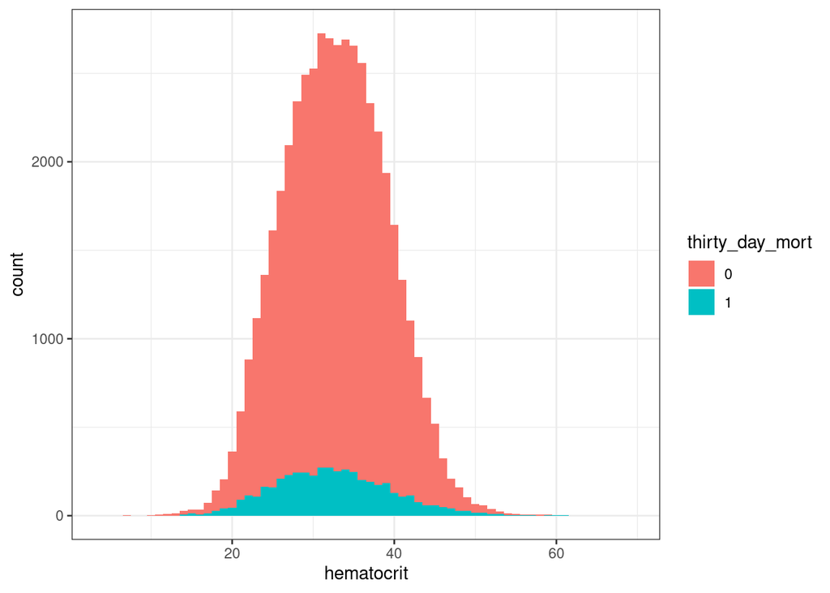

```r
# histogram
mimic_icu_cohort %>%
  mutate(thirty_day_mort = factor(as.character(thirty_day_mort))) %>%
  ggplot(aes(x = hematocrit, fill = thirty_day_mort)) +
  geom_histogram(position = "identity", binwidth = 1) +
  theme_bw()
```

5. white blood cell count

```r
# summary
mimic_icu_cohort %>%
  group_by(thirty_day_mort) %>%
  dplyr::summarise(min = min(wbcc, na.rm = T),
                   Q1 = quantile(wbcc, .25, na.rm = T),
                   mean = mean(wbcc, na.rm = T),
                   median = median(wbcc, na.rm = T),
                   Q3 = quantile(wbcc, .75, na.rm = T),
                   max = max(wbcc, na.rm = T),
                   # count of NAs
                   na = sum(is.na(wbcc)),
                   N = n())
```

```
## # A tibble: 2 × 9
##   thirty_day_mort   min    Q1  mean median    Q3   max    na     N
##             <dbl> <dbl> <dbl> <dbl>  <dbl> <dbl> <dbl> <int> <int>
## 1               0   0     7.5  11.7   10.3  14.1  572.   455 47855
## 2               1   0.1   8.6  15.2   12.6  18.1  472.   436  5210
```

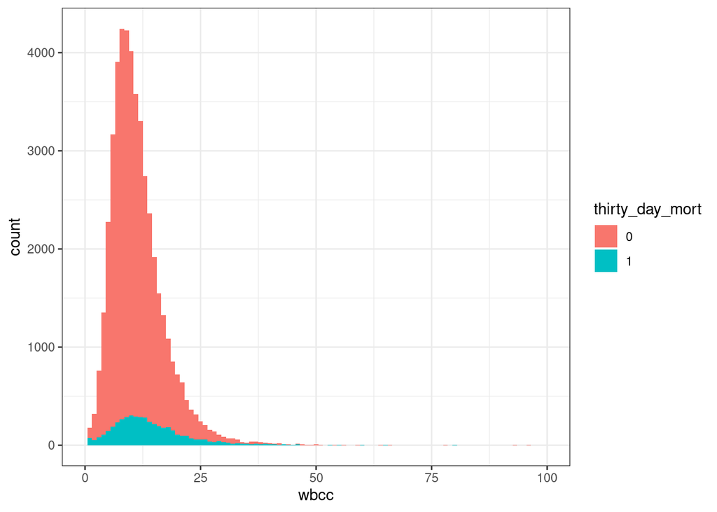

```r
# histogram
mimic_icu_cohort %>%
  mutate(thirty_day_mort = factor(as.character(thirty_day_mort))) %>%
  ggplot(aes(x = wbcc, fill = thirty_day_mort)) +
  geom_histogram(position = "identity", binwidth = 1) +
  xlim(0, 100) +
  theme_bw()
```

6. glucose

```r
# summary
mimic_icu_cohort %>%
  group_by(thirty_day_mort) %>%
  dplyr::summarise(min = min(glucose, na.rm = T),
                   Q1 = quantile(glucose, .25, na.rm = T),
                   mean = mean(glucose, na.rm = T),
                   median = median(glucose, na.rm = T),
                   Q3 = quantile(glucose, .75, na.rm = T),
                   max = max(glucose, na.rm = T),
                   # count of NAs
                   na = sum(is.na(glucose)),
                   N = n())
```

```
## # A tibble: 2 × 9
##   thirty_day_mort   min    Q1  mean median    Q3   max    na     N
##             <dbl> <dbl> <dbl> <dbl>  <dbl> <dbl> <dbl> <int> <int>
## 1               0     8   102  139.    123   153  2440   296 47855
## 2               1     7   108  164.    139   189  1429   412  5210
```

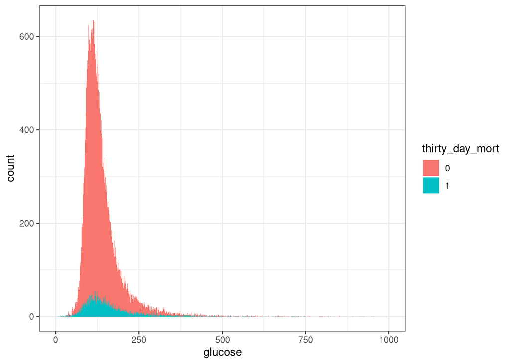

```r
# histogram
mimic_icu_cohort %>%
  mutate(thirty_day_mort = factor(as.character(thirty_day_mort))) %>%
  ggplot(aes(x = glucose, fill = thirty_day_mort)) +
  geom_histogram(position = "identity", binwidth = 1) +
  xlim(0, 1000) +
  theme_bw()
```

7. magnesium

```r
# summary
mimic_icu_cohort %>%
  group_by(thirty_day_mort) %>%
  dplyr::summarise(min = min(magnesium, na.rm = T),
                   Q1 = quantile(magnesium, .25, na.rm = T),
                   mean = mean(magnesium, na.rm = T),
                   median = median(magnesium, na.rm = T),
                   Q3 = quantile(magnesium, .75, na.rm = T),
                   max = max(magnesium, na.rm = T),
                   # count of NAs
                   na = sum(is.na(magnesium)),
                   N = n())
```

```
## # A tibble: 2 × 9
##   thirty_day_mort   min    Q1  mean median    Q3   max    na     N
##             <dbl> <dbl> <dbl> <dbl>  <dbl> <dbl> <dbl> <int> <int>
## 1               0   0     1.7  2.00      2   2.2  47     428 47855
## 2               1   0.5   1.7  2.03      2   2.2   8.7   427  5210
```

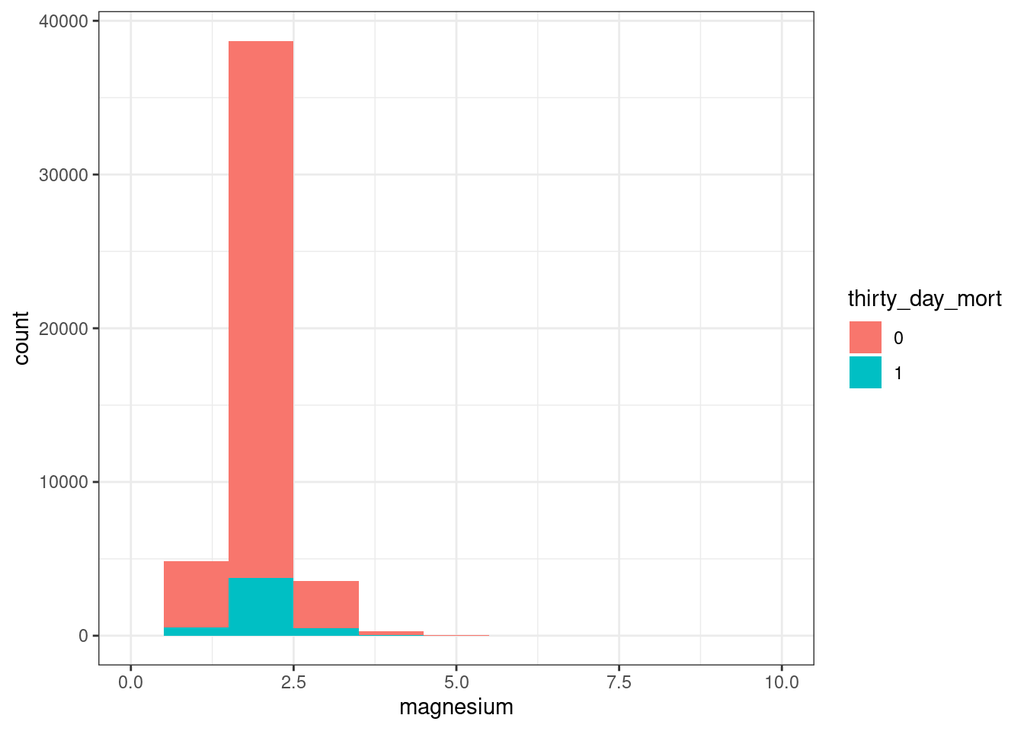

```r
# histogram
mimic_icu_cohort %>%
  mutate(thirty_day_mort = factor(as.character(thirty_day_mort))) %>%
  ggplot(aes(x = magnesium, fill = thirty_day_mort)) +
  geom_histogram(position = "identity", binwidth = 1) +
  xlim(0, 10) +
  theme_bw()
```

8. calcium

```r
# summary
mimic_icu_cohort %>%
  group_by(thirty_day_mort) %>%
  dplyr::summarise(min = min(calcium, na.rm = T),
                   Q1 = quantile(calcium, .25, na.rm = T),
                   mean = mean(calcium, na.rm = T),
                   median = median(calcium, na.rm = T),
                   Q3 = quantile(calcium, .75, na.rm = T),
                   max = max(calcium, na.rm = T),
                   # count of NAs
                   na = sum(is.na(calcium)),
                   N = n())
```

```
## # A tibble: 2 × 9
##   thirty_day_mort   min    Q1  mean median    Q3   max    na     N
##             <dbl> <dbl> <dbl> <dbl>  <dbl> <dbl> <dbl> <int> <int>
## 1               0   0     7.9  8.38    8.4   8.9  27.5  1408 47855
## 2               1   1.6   7.6  8.22    8.2   8.8  43     430  5210
```

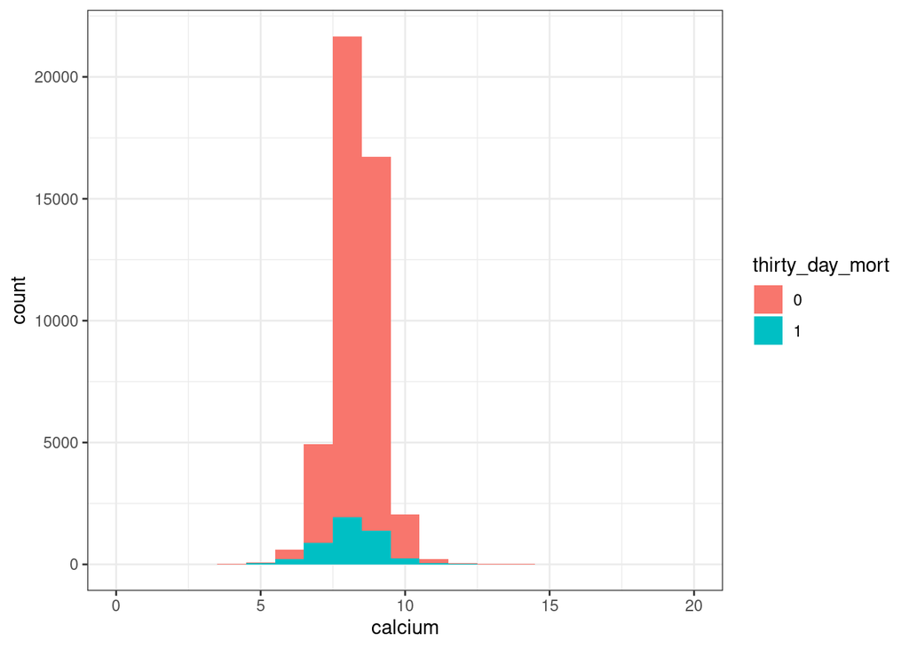

```r
# histogram
mimic_icu_cohort %>%
  mutate(thirty_day_mort = factor(as.character(thirty_day_mort))) %>%
  ggplot(aes(x = calcium, fill = thirty_day_mort)) +
  geom_histogram(position = "identity", binwidth = 1) +
  xlim(0, 20) +
  theme_bw()
```

9. chloride

```r
# summary
mimic_icu_cohort %>%
  group_by(thirty_day_mort) %>%
  dplyr::summarise(min = min(chloride, na.rm = T),
                   Q1 = quantile(chloride, .25, na.rm = T),
                   mean = mean(chloride, na.rm = T),
                   median = median(chloride, na.rm = T),
                   Q3 = quantile(chloride, .75, na.rm = T),
                   max = max(chloride, na.rm = T),
                   # count of NAs
                   na = sum(is.na(chloride)),
                   N = n())
```

```
## # A tibble: 2 × 9
##   thirty_day_mort   min    Q1  mean median    Q3   max    na     N
##             <dbl> <dbl> <dbl> <dbl>  <dbl> <dbl> <dbl> <int> <int>
## 1               0    58   101  105.    105   108   153   294 47855
## 2               1    61    99  103.    104   108   140   403  5210
```

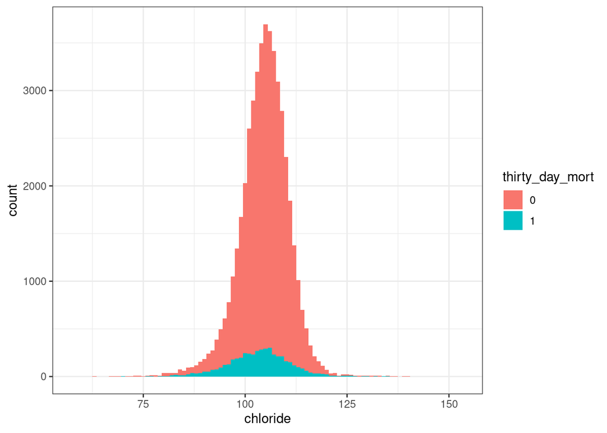

```r
# histogram
mimic_icu_cohort %>%
  mutate(thirty_day_mort = factor(as.character(thirty_day_mort))) %>%
  ggplot(aes(x = chloride, fill = thirty_day_mort)) +
  geom_histogram(position = "identity", binwidth = 1) +
  theme_bw()
```

10. bicarbonate

```r
# summary
mimic_icu_cohort %>%
  group_by(thirty_day_mort) %>%
  dplyr::summarise(min = min(bicarbonate, na.rm = T),
                   Q1 = quantile(bicarbonate, .25, na.rm = T),
                   mean = mean(bicarbonate, na.rm = T),
                   median = median(bicarbonate, na.rm = T),
                   Q3 = quantile(bicarbonate, .75, na.rm = T),
                   max = max(bicarbonate, na.rm = T),
                   # count of NAs
                   na = sum(is.na(bicarbonate)),
                   N = n())
```

```
## # A tibble: 2 × 9
##   thirty_day_mort   min    Q1  mean median    Q3   max    na     N
##             <dbl> <dbl> <dbl> <dbl>  <dbl> <dbl> <dbl> <int> <int>
## 1               0     3    21  23.2     23    26    49   310 47855
## 2               1     2    17  20.9     21    24    48   410  5210
```

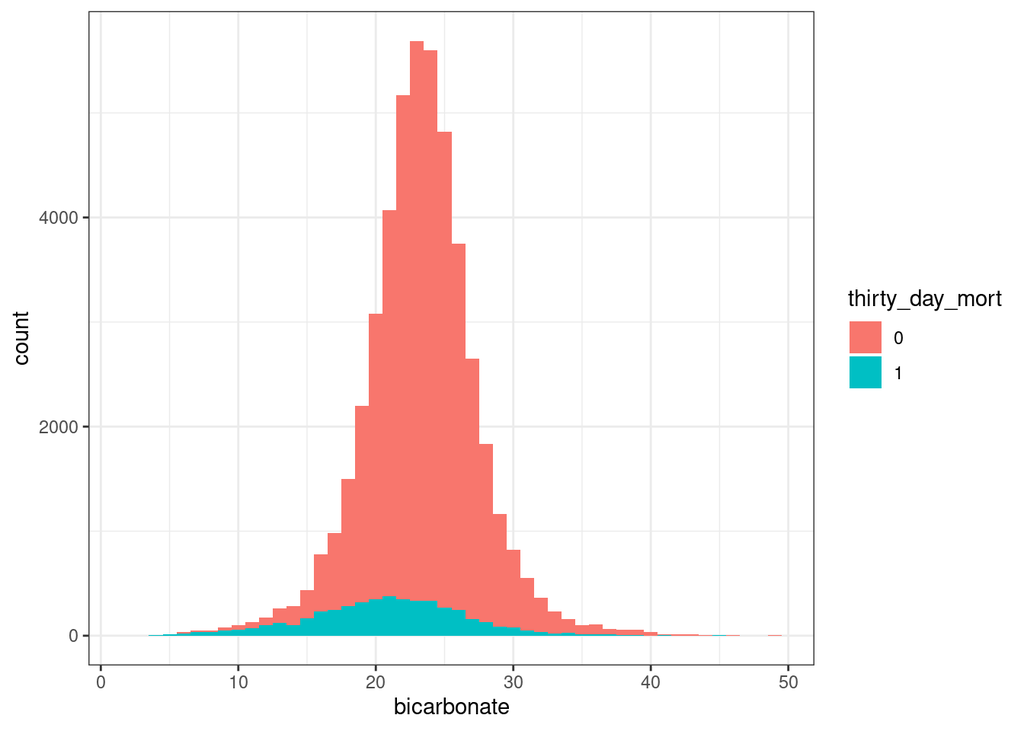

```r
# histogram
mimic_icu_cohort %>%
  mutate(thirty_day_mort = factor(as.character(thirty_day_mort))) %>%
  ggplot(aes(x = bicarbonate, fill = thirty_day_mort)) +
  geom_histogram(position = "identity", binwidth = 1) +
  theme_bw()
```

- `thirty_day_mort` vs first vital measurements  
  **Answer:**  
  Overall boxplot.

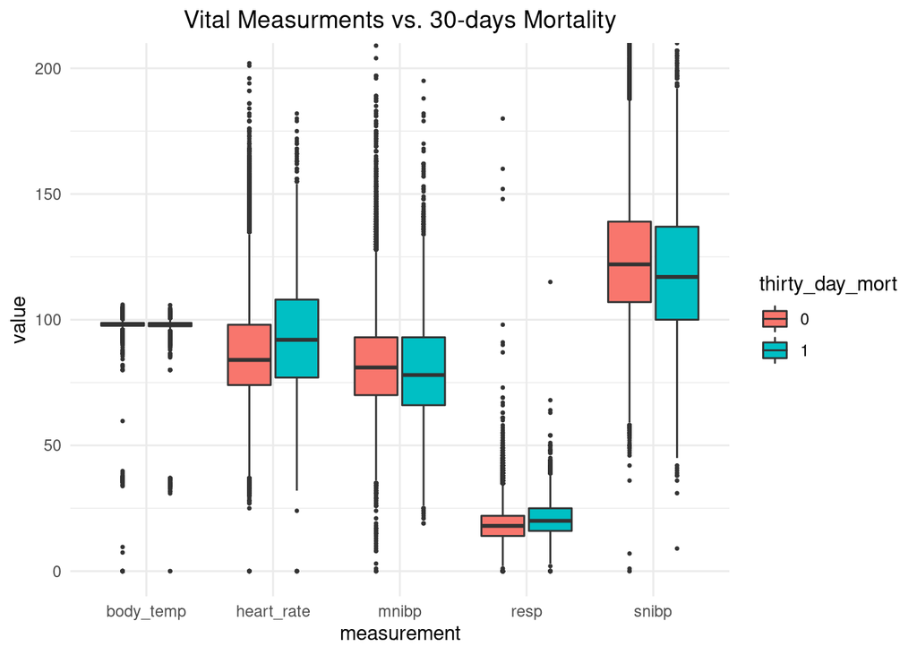

```r
df %>%
  filter(measurement %in% c("heart_rate", "mnibp", "snibp", "body_temp", "resp")) %>%
  ggplot(aes(x = measurement, y = value, fill = thirty_day_mort)) +
  geom_boxplot(outlier.size = 0.5) +
  coord_cartesian(ylim = c(0, 200)) +
  theme_minimal() +
  labs(title = "Vital Measurments vs. 30-days Mortality") +
  theme(plot.title = element_text(hjust = 0.5))
```

1. heart rate

```r
# summary
mimic_icu_cohort %>%
  group_by(thirty_day_mort) %>%
  dplyr::summarise(min = min(heart_rate, na.rm = T),
                   Q1 = quantile(heart_rate, .25, na.rm = T),
                   mean = mean(heart_rate, na.rm = T),
                   median = median(heart_rate, na.rm = T),
                   Q3 = quantile(heart_rate, .75, na.rm = T),
                   max = max(heart_rate, na.rm = T),
                   # count of NAs
                   na = sum(is.na(heart_rate)),
                   N = n())
```

```
## # A tibble: 2 × 9
##   thirty_day_mort   min    Q1  mean median    Q3   max    na     N
##             <dbl> <dbl> <dbl> <dbl>  <dbl> <dbl> <dbl> <int> <int>
## 1               0     0    74  86.8     84    98   941     1 47855
## 2               1     0    77  93.2     92   108   182     0  5210
```

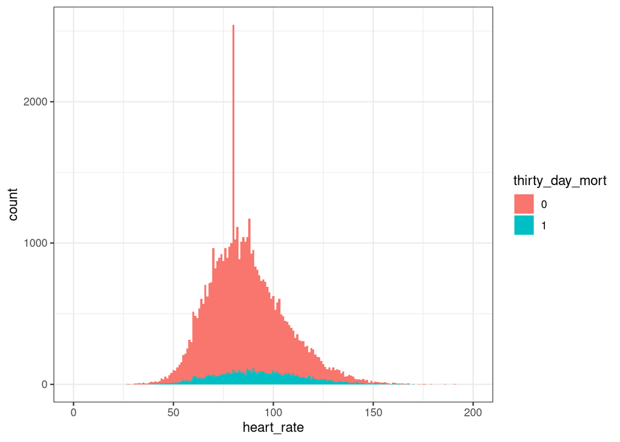

```r
# histogram
mimic_icu_cohort %>%
  mutate(thirty_day_mort = factor(as.character(thirty_day_mort))) %>%
  ggplot(aes(x = heart_rate, fill = thirty_day_mort)) +
  geom_histogram(position = "identity", binwidth = 1) +
  xlim(0, 200) +
  theme_bw()
```

2. mean non-invasive blood pressure

```r
# summary
mimic_icu_cohort %>%
  group_by(thirty_day_mort) %>%
  dplyr::summarise(min = min(mnibp, na.rm = T),
                   Q1 = quantile(mnibp, .25, na.rm = T),
                   mean = mean(mnibp, na.rm = T),
                   median = median(mnibp, na.rm = T),
                   Q3 = quantile(mnibp, .75, na.rm = T),
                   max = max(mnibp, na.rm = T),
                   # count of NAs
                   na = sum(is.na(mnibp)),
                   N = n())
```

```
## # A tibble: 2 × 9
##   thirty_day_mort   min    Q1  mean median    Q3    max    na     N
##             <dbl> <dbl> <dbl> <dbl>  <dbl> <dbl>  <dbl> <int> <int>
## 1               0     0    70  85.2     81    93 120130   286 47855
## 2               1    19    66 109.      78    93 140119   247  5210
```

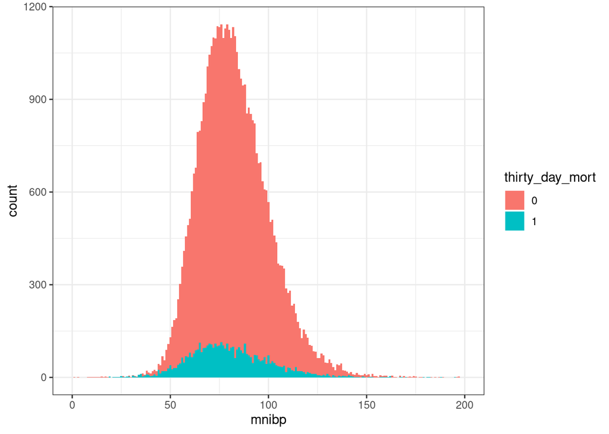

```r
# histogram
mimic_icu_cohort %>%
  mutate(thirty_day_mort = factor(as.character(thirty_day_mort))) %>%
  ggplot(aes(x = mnibp, fill = thirty_day_mort)) +
  geom_histogram(position = "identity", binwidth = 1) +
  xlim(0, 200) +
  theme_bw()
```

3. systolic non-invasive blood pressure

```r
# summary
mimic_icu_cohort %>%
  group_by(thirty_day_mort) %>%
  dplyr::summarise(min = min(snibp, na.rm = T),
                   Q1 = quantile(snibp, .25, na.rm = T),
                   mean = mean(snibp, na.rm = T),
                   median = median(snibp, na.rm = T),
                   Q3 = quantile(snibp, .75, na.rm = T),
                   max = max(snibp, na.rm = T),
                   # count of NAs
                   na = sum(is.na(snibp)),
                   N = n())
```

```
## # A tibble: 2 × 9
##   thirty_day_mort   min    Q1  mean median    Q3   max    na     N
##             <dbl> <dbl> <dbl> <dbl>  <dbl> <dbl> <dbl> <int> <int>
## 1               0     0   107  124.    122   139   259   263 47855
## 2               1     9   100  122.    117   137 12262   249  5210
```

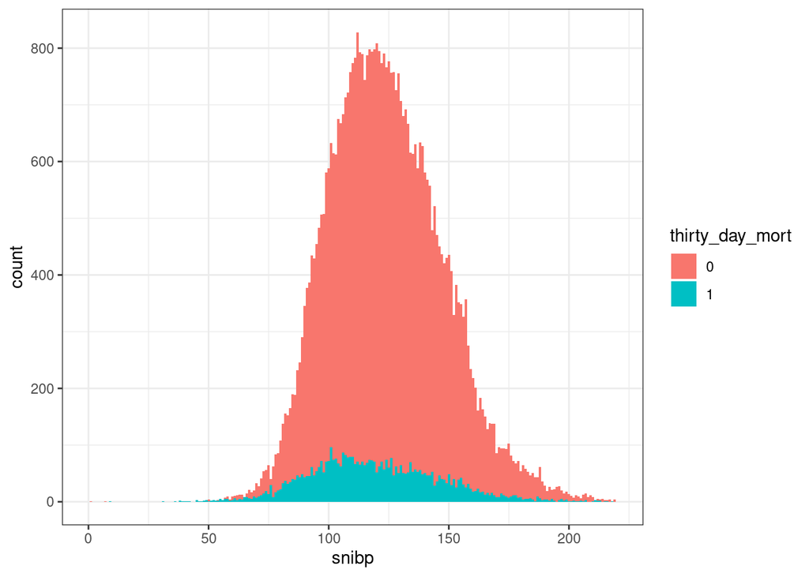

```r
# histogram
mimic_icu_cohort %>%
  mutate(thirty_day_mort = factor(as.character(thirty_day_mort))) %>%
  ggplot(aes(x = snibp, fill = thirty_day_mort)) +
  geom_histogram(position = "identity", binwidth = 1) +
  xlim(0, 220) +
  theme_bw()
```

4. body temperature in Fahrenheit

```r
# summary
mimic_icu_cohort %>%
  group_by(thirty_day_mort) %>%
  dplyr::summarise(min = min(body_temp, na.rm = T),
                   Q1 = quantile(body_temp, .25, na.rm = T),
                   mean = mean(body_temp, na.rm = T),
                   median = median(body_temp, na.rm = T),
                   Q3 = quantile(body_temp, .75, na.rm = T),
                   max = max(body_temp, na.rm = T),
                   # count of NAs
                   na = sum(is.na(body_temp)),
                   N = n())
```

```
## # A tibble: 2 × 9
##   thirty_day_mort   min    Q1  mean median    Q3   max    na     N
##             <dbl> <dbl> <dbl> <dbl>  <dbl> <dbl> <dbl> <int> <int>
## 1               0     0  97.6  98.1   98.2  98.7  106    356 47855
## 2               1     0  97.4  97.5   98    98.7  106.   463  5210
```

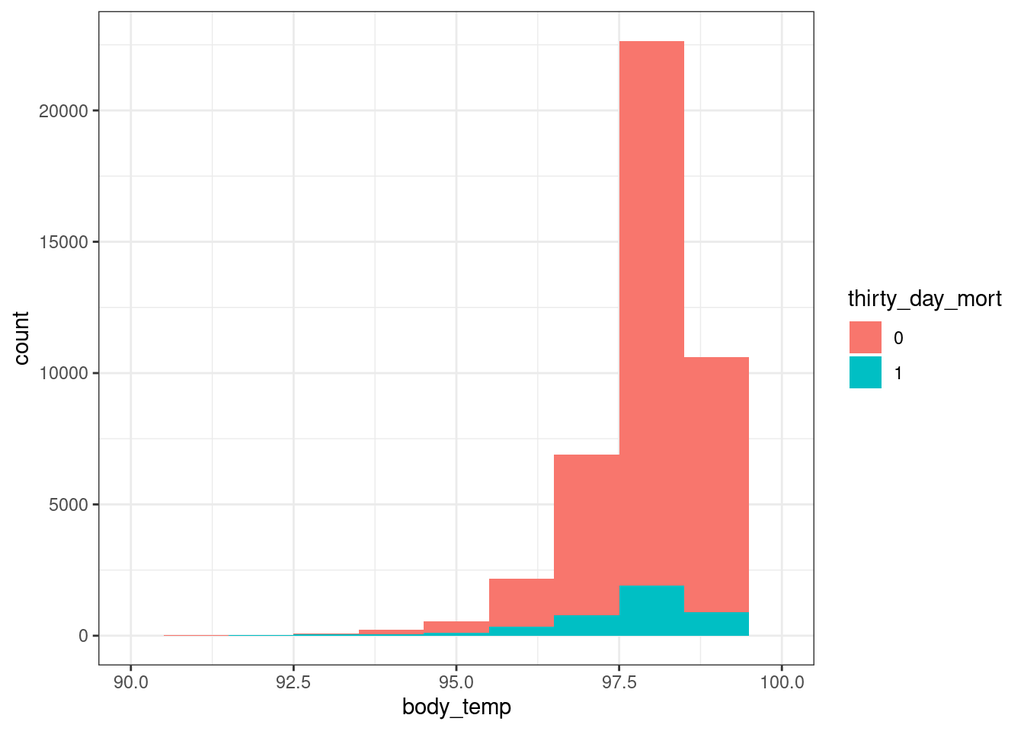

```r
# histogram
mimic_icu_cohort %>%
  mutate(thirty_day_mort = factor(as.character(thirty_day_mort))) %>%
  ggplot(aes(x = body_temp, fill = thirty_day_mort)) +
  geom_histogram(position = "identity", binwidth = 1) +
  xlim(90, 100) +
  theme_bw()
```

5. respiratory rate

```r
# summary
mimic_icu_cohort %>%
  group_by(thirty_day_mort) %>%
  dplyr::summarise(min = min(resp, na.rm = T),
                   Q1 = quantile(resp, .25, na.rm = T),
                   mean = mean(resp, na.rm = T),
                   median = median(resp, na.rm = T),
                   Q3 = quantile(resp, .75, na.rm = T),
                   max = max(resp, na.rm = T),
                   # count of NAs
                   na = sum(is.na(resp)),
                   N = n())
```

```
## # A tibble: 2 × 9
##   thirty_day_mort   min    Q1  mean median    Q3   max    na     N
##             <dbl> <dbl> <dbl> <dbl>  <dbl> <dbl> <dbl> <int> <int>
## 1               0     0    14  18.4     18    22   180    31 47855
## 2               1     0    16  21.1     20    25   115     6  5210
```

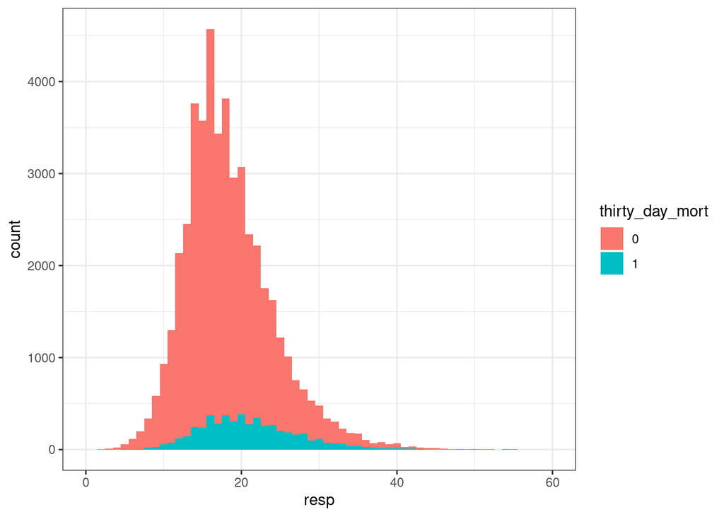

```r
# histogram
mimic_icu_cohort %>%
  mutate(thirty_day_mort = factor(as.character(thirty_day_mort))) %>%
  ggplot(aes(x = resp, fill = thirty_day_mort)) +
  geom_histogram(position = "identity", binwidth = 1) +
  xlim(0, 60) +
  theme_bw()
```

- `thirty_day_mort` vs first ICU unit

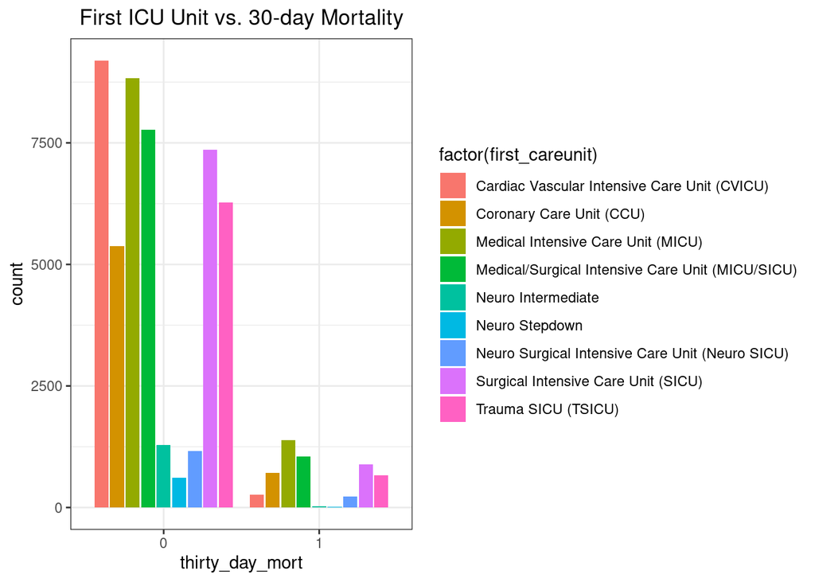

```r
mimic_icu_cohort %>%
  ggplot(aes(x = factor(as.character(thirty_day_mort)),
             fill = factor(first_careunit))) +
  geom_bar(position = "dodge2") +
  labs(title = "First ICU Unit vs. 30-day Mortality", x = "thirty_day_mort",
       y = "count") +
  theme_bw() +
  theme(plot.title = element_text(hjust = 0.5))
```